# Risk Factor Analysis

## Outcome Variable

**Outcome Variable:** stunted

## Predictor Variables

**Intervention Variable:** vagbrth

**Adjustment Set:**

unadjusted

## Stratifying Variables

The analysis was stratified on these variable(s):

- agecat
- studyid
- country

## Data Summary

| agecat | studyid | country | vagbrth | stunted | n_cell | n |
| --- | --- | --- | --- | --- | --- | --- |
| Birth | CMC-V-BCS-2002 | INDIA | 0 | 0 | 9 | 92 |
| Birth | CMC-V-BCS-2002 | INDIA | 0 | 1 | 2 | 92 |
| Birth | CMC-V-BCS-2002 | INDIA | 1 | 0 | 66 | 92 |
| Birth | CMC-V-BCS-2002 | INDIA | 1 | 1 | 15 | 92 |
| Birth | IRC | INDIA | 0 | 0 | 58 | 388 |
| Birth | IRC | INDIA | 0 | 1 | 10 | 388 |
| Birth | IRC | INDIA | 1 | 0 | 285 | 388 |
| Birth | IRC | INDIA | 1 | 1 | 35 | 388 |
| Birth | JiVitA-3 | BANGLADESH | 0 | 0 | 418 | 22418 |
| Birth | JiVitA-3 | BANGLADESH | 0 | 1 | 121 | 22418 |
| Birth | JiVitA-3 | BANGLADESH | 1 | 0 | 14626 | 22418 |
| Birth | JiVitA-3 | BANGLADESH | 1 | 1 | 7253 | 22418 |
| Birth | JiVitA-4 | BANGLADESH | 0 | 0 | 57 | 2822 |
| Birth | JiVitA-4 | BANGLADESH | 0 | 1 | 19 | 2822 |
| Birth | JiVitA-4 | BANGLADESH | 1 | 0 | 1908 | 2822 |
| Birth | JiVitA-4 | BANGLADESH | 1 | 1 | 838 | 2822 |
| Birth | NIH-Crypto | BANGLADESH | 0 | 0 | 160 | 477 |
| Birth | NIH-Crypto | BANGLADESH | 0 | 1 | 26 | 477 |
| Birth | NIH-Crypto | BANGLADESH | 1 | 0 | 253 | 477 |
| Birth | NIH-Crypto | BANGLADESH | 1 | 1 | 38 | 477 |
| Birth | PROBIT | BELARUS | 0 | 0 | 1595 | 13893 |
| Birth | PROBIT | BELARUS | 0 | 1 | 2 | 13893 |
| Birth | PROBIT | BELARUS | 1 | 0 | 12264 | 13893 |
| Birth | PROBIT | BELARUS | 1 | 1 | 32 | 13893 |
| Birth | PROVIDE | BANGLADESH | 0 | 0 | 98 | 539 |
| Birth | PROVIDE | BANGLADESH | 0 | 1 | 10 | 539 |
| Birth | PROVIDE | BANGLADESH | 1 | 0 | 393 | 539 |
| Birth | PROVIDE | BANGLADESH | 1 | 1 | 38 | 539 |
| Birth | ZVITAMBO | ZIMBABWE | 0 | 0 | 1076 | 13761 |
| Birth | ZVITAMBO | ZIMBABWE | 0 | 1 | 90 | 13761 |

[output cut: 74 more lines]

The following strata were considered:

- agecat: 24 months, studyid: CMC-V-BCS-2002, country: INDIA
- agecat: 24 months, studyid: IRC, country: INDIA
- agecat: 24 months, studyid: JiVitA-3, country: BANGLADESH
- agecat: 24 months, studyid: JiVitA-4, country: BANGLADESH
- agecat: 24 months, studyid: NIH-Crypto, country: BANGLADESH
- agecat: 24 months, studyid: PROBIT, country: BELARUS
- agecat: 24 months, studyid: PROVIDE, country: BANGLADESH
- agecat: 24 months, studyid: TanzaniaChild2, country: TANZANIA, UNITED REPUBLIC OF
- agecat: 24 months, studyid: ZVITAMBO, country: ZIMBABWE
- agecat: 6 months, studyid: CMC-V-BCS-2002, country: INDIA
- agecat: 6 months, studyid: IRC, country: INDIA
- agecat: 6 months, studyid: JiVitA-3, country: BANGLADESH
- agecat: 6 months, studyid: JiVitA-4, country: BANGLADESH
- agecat: 6 months, studyid: NIH-Crypto, country: BANGLADESH
- agecat: 6 months, studyid: PROBIT, country: BELARUS
- agecat: 6 months, studyid: PROVIDE, country: BANGLADESH
- agecat: 6 months, studyid: TanzaniaChild2, country: TANZANIA, UNITED REPUBLIC OF
- agecat: 6 months, studyid: ZVITAMBO, country: ZIMBABWE
- agecat: Birth, studyid: CMC-V-BCS-2002, country: INDIA
- agecat: Birth, studyid: IRC, country: INDIA
- agecat: Birth, studyid: JiVitA-3, country: BANGLADESH
- agecat: Birth, studyid: JiVitA-4, country: BANGLADESH
- agecat: Birth, studyid: NIH-Crypto, country: BANGLADESH
- agecat: Birth, studyid: PROBIT, country: BELARUS
- agecat: Birth, studyid: PROVIDE, country: BANGLADESH
- agecat: Birth, studyid: ZVITAMBO, country: ZIMBABWE

### Dropped Strata

Some strata were dropped due to rare outcomes:

- agecat: Birth, studyid: CMC-V-BCS-2002, country: INDIA
- agecat: Birth, studyid: PROBIT, country: BELARUS
- agecat: 24 months, studyid: TanzaniaChild2, country: TANZANIA, UNITED REPUBLIC OF

## Methods Detail

We’re interested in the causal parameters $E[Y_a]$ for all values of $a \in \mathcal{A}$. These parameters represent the mean outcome if, possibly contrary to fact, we intervened to set all units to have $A=a$. Under the randomization and positivity assumptions, these are identified by the statistical parameters $\psi_a=E_W[E_{Y|A,W}(Y|A=a,W)]$. In addition, we’re interested in the mean of $Y$, $E[Y]$ under no intervention (the observed mean). We will estimate these parameters by using SuperLearner to fit the relevant likelihood factors – $E_{Y|A,W}(Y|A=a,W)$ and $p(A=a|W)$, and then updating our likelihood fit using a joint TMLE.

For unadjusted analyses ($W=\{\}$), initial likelihoods were estimated using Lrnr_glm to estimate the simple $E(Y|A)$ and Lrnr_mean to estimate $p(A)$. For adjusted analyses, a small library containing Lrnr_glmnet, Lrnr_xgboost, and Lrnr_mean was used.

Having estimated these parameters, we will then use the delta method to estimate relative risks and attributable risks relative to a prespecified baseline level of $A$.

# Results Detail

## Results Plots

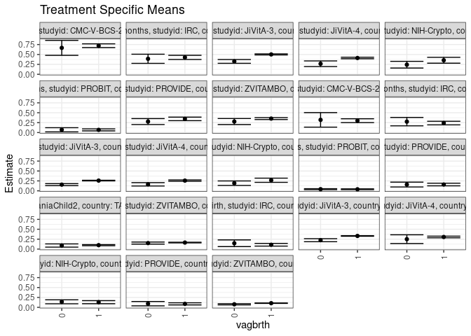

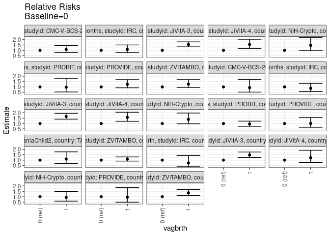

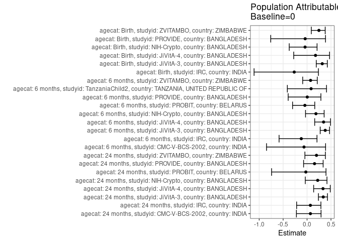

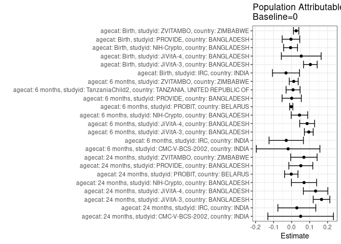

## Results Table

### Parameter: TSM

| agecat | studyid | country | intervention_level | baseline_level | estimate | ci_lower | ci_upper |
| --- | --- | --- | --- | --- | --- | --- | --- |
| Birth | IRC | INDIA | 0 | NA | 0.1470588 | 0.0627721 | 0.2313455 |
| Birth | IRC | INDIA | 1 | NA | 0.1093750 | 0.0751345 | 0.1436155 |
| Birth | JiVitA-3 | BANGLADESH | 0 | NA | 0.2244898 | 0.1862733 | 0.2627063 |
| Birth | JiVitA-3 | BANGLADESH | 1 | NA | 0.3315051 | 0.3240687 | 0.3389414 |
| Birth | JiVitA-4 | BANGLADESH | 0 | NA | 0.2500000 | 0.1393237 | 0.3606763 |
| Birth | JiVitA-4 | BANGLADESH | 1 | NA | 0.3051712 | 0.2846846 | 0.3256577 |
| Birth | NIH-Crypto | BANGLADESH | 0 | NA | 0.1397849 | 0.0898987 | 0.1896712 |
| Birth | NIH-Crypto | BANGLADESH | 1 | NA | 0.1305842 | 0.0918302 | 0.1693382 |
| Birth | PROVIDE | BANGLADESH | 0 | NA | 0.0925926 | 0.0378748 | 0.1473104 |
| Birth | PROVIDE | BANGLADESH | 1 | NA | 0.0881671 | 0.0613739 | 0.1149602 |
| Birth | ZVITAMBO | ZIMBABWE | 0 | NA | 0.0771870 | 0.0618675 | 0.0925064 |
| Birth | ZVITAMBO | ZIMBABWE | 1 | NA | 0.1049623 | 0.0996092 | 0.1103153 |
| 6 months | CMC-V-BCS-2002 | INDIA | 0 | NA | 0.3200000 | 0.1368964 | 0.5031036 |
| 6 months | CMC-V-BCS-2002 | INDIA | 1 | NA | 0.2994186 | 0.2509538 | 0.3478835 |
| 6 months | IRC | INDIA | 0 | NA | 0.2753623 | 0.1698337 | 0.3808910 |
| 6 months | IRC | INDIA | 1 | NA | 0.2396450 | 0.1940816 | 0.2852084 |
| 6 months | JiVitA-3 | BANGLADESH | 0 | NA | 0.1559889 | 0.1308441 | 0.1811336 |
| 6 months | JiVitA-3 | BANGLADESH | 1 | NA | 0.2581284 | 0.2497891 | 0.2664676 |
| 6 months | JiVitA-4 | BANGLADESH | 0 | NA | 0.1636905 | 0.1215487 | 0.2058322 |
| 6 months | JiVitA-4 | BANGLADESH | 1 | NA | 0.2578041 | 0.2408233 | 0.2747849 |
| 6 months | NIH-Crypto | BANGLADESH | 0 | NA | 0.1925134 | 0.1359414 | 0.2490853 |
| 6 months | NIH-Crypto | BANGLADESH | 1 | NA | 0.2666667 | 0.2138614 | 0.3194719 |
| 6 months | PROBIT | BELARUS | 0 | NA | 0.0411340 | 0.0292129 | 0.0530550 |
| 6 months | PROBIT | BELARUS | 1 | NA | 0.0391089 | 0.0288156 | 0.0494023 |
| 6 months | PROVIDE | BANGLADESH | 0 | NA | 0.1582734 | 0.0975452 | 0.2190015 |
| 6 months | PROVIDE | BANGLADESH | 1 | NA | 0.1591398 | 0.1258637 | 0.1924159 |
| 6 months | TanzaniaChild2 | TANZANIA, UNITED REPUBLIC OF | 0 | NA | 0.0899471 | 0.0491478 | 0.1307464 |
| 6 months | TanzaniaChild2 | TANZANIA, UNITED REPUBLIC OF | 1 | NA | 0.0991189 | 0.0853719 | 0.1128660 |
| 6 months | ZVITAMBO | ZIMBABWE | 0 | NA | 0.1513514 | 0.1255279 | 0.1771748 |
| 6 months | ZVITAMBO | ZIMBABWE | 1 | NA | 0.1644829 | 0.1562874 | 0.1726783 |
| 24 months | CMC-V-BCS-2002 | INDIA | 0 | NA | 0.6666667 | 0.4778144 | 0.8555190 |
| 24 months | CMC-V-BCS-2002 | INDIA | 1 | NA | 0.7204611 | 0.6731791 | 0.7677431 |
| 24 months | IRC | INDIA | 0 | NA | 0.3913043 | 0.2760088 | 0.5065999 |
| 24 months | IRC | INDIA | 1 | NA | 0.4264706 | 0.3738370 | 0.4791041 |
| 24 months | JiVitA-3 | BANGLADESH | 0 | NA | 0.3250000 | 0.2773712 | 0.3726288 |
| 24 months | JiVitA-3 | BANGLADESH | 1 | NA | 0.5011106 | 0.4878291 | 0.5143920 |
| 24 months | JiVitA-4 | BANGLADESH | 0 | NA | 0.2662539 | 0.1948801 | 0.3376276 |
| 24 months | JiVitA-4 | BANGLADESH | 1 | NA | 0.4111442 | 0.3919032 | 0.4303852 |
| 24 months | NIH-Crypto | BANGLADESH | 0 | NA | 0.2424242 | 0.1578441 | 0.3270044 |
| 24 months | NIH-Crypto | BANGLADESH | 1 | NA | 0.3540373 | 0.2800256 | 0.4280489 |
| 24 months | PROBIT | BELARUS | 0 | NA | 0.0699153 | 0.0172098 | 0.1226208 |
| 24 months | PROBIT | BELARUS | 1 | NA | 0.0679203 | 0.0431814 | 0.0926592 |
| 24 months | PROVIDE | BANGLADESH | 0 | NA | 0.2773723 | 0.2023392 | 0.3524053 |
| 24 months | PROVIDE | BANGLADESH | 1 | NA | 0.3446712 | 0.3002759 | 0.3890665 |
| 24 months | ZVITAMBO | ZIMBABWE | 0 | NA | 0.2781955 | 0.2020154 | 0.3543755 |
| 24 months | ZVITAMBO | ZIMBABWE | 1 | NA | 0.3526245 | 0.3283244 | 0.3769245 |

### Parameter: E(Y)

| agecat | studyid | country | intervention_level | baseline_level | estimate | ci_lower | ci_upper |
| --- | --- | --- | --- | --- | --- | --- | --- |
| Birth | IRC | INDIA | NA | NA | 0.1159794 | 0.0840777 | 0.1478811 |
| Birth | JiVitA-3 | BANGLADESH | NA | NA | 0.3289321 | 0.3215578 | 0.3363064 |
| Birth | JiVitA-4 | BANGLADESH | NA | NA | 0.3036853 | 0.2836812 | 0.3236894 |
| Birth | NIH-Crypto | BANGLADESH | NA | NA | 0.1341719 | 0.1035529 | 0.1647909 |
| Birth | PROVIDE | BANGLADESH | NA | NA | 0.0890538 | 0.0649864 | 0.1131212 |
| Birth | ZVITAMBO | ZIMBABWE | NA | NA | 0.1026088 | 0.0975387 | 0.1076790 |
| 6 months | CMC-V-BCS-2002 | INDIA | NA | NA | 0.3008130 | 0.2539566 | 0.3476694 |
| 6 months | IRC | INDIA | NA | NA | 0.2457002 | 0.2038248 | 0.2875757 |
| 6 months | JiVitA-3 | BANGLADESH | NA | NA | 0.2515539 | 0.2434271 | 0.2596807 |
| 6 months | JiVitA-4 | BANGLADESH | NA | NA | 0.2500000 | 0.2338924 | 0.2661076 |
| 6 months | NIH-Crypto | BANGLADESH | NA | NA | 0.2363239 | 0.1973320 | 0.2753157 |
| 6 months | PROBIT | BELARUS | NA | NA | 0.0393401 | 0.0293640 | 0.0493162 |
| 6 months | PROVIDE | BANGLADESH | NA | NA | 0.1589404 | 0.1297581 | 0.1881227 |
| 6 months | TanzaniaChild2 | TANZANIA, UNITED REPUBLIC OF | NA | NA | 0.0982544 | 0.0852222 | 0.1112865 |
| 6 months | ZVITAMBO | ZIMBABWE | NA | NA | 0.1633531 | 0.1555398 | 0.1711664 |
| 24 months | CMC-V-BCS-2002 | INDIA | NA | NA | 0.7169811 | 0.6710815 | 0.7628807 |
| 24 months | IRC | INDIA | NA | NA | 0.4205379 | 0.3726382 | 0.4684376 |
| 24 months | JiVitA-3 | BANGLADESH | NA | NA | 0.4912628 | 0.4781447 | 0.5043809 |
| 24 months | JiVitA-4 | BANGLADESH | NA | NA | 0.3995025 | 0.3807924 | 0.4182126 |
| 24 months | NIH-Crypto | BANGLADESH | NA | NA | 0.3115385 | 0.2551365 | 0.3679404 |
| 24 months | PROBIT | BELARUS | NA | NA | 0.0681537 | 0.0420376 | 0.0942697 |
| 24 months | PROVIDE | BANGLADESH | NA | NA | 0.3287197 | 0.2903909 | 0.3670485 |
| 24 months | ZVITAMBO | ZIMBABWE | NA | NA | 0.3465102 | 0.3233236 | 0.3696967 |

### Parameter: RR

| agecat | studyid | country | intervention_level | baseline_level | estimate | ci_lower | ci_upper |
| --- | --- | --- | --- | --- | --- | --- | --- |
| Birth | IRC | INDIA | 0 | 0 | 1.0000000 | 1.0000000 | 1.000000 |
| Birth | IRC | INDIA | 1 | 0 | 0.7437500 | 0.3870802 | 1.429068 |
| Birth | JiVitA-3 | BANGLADESH | 0 | 0 | 1.0000000 | 1.0000000 | 1.000000 |
| Birth | JiVitA-3 | BANGLADESH | 1 | 0 | 1.4767045 | 1.2444934 | 1.752244 |
| Birth | JiVitA-4 | BANGLADESH | 0 | 0 | 1.0000000 | 1.0000000 | 1.000000 |
| Birth | JiVitA-4 | BANGLADESH | 1 | 0 | 1.2206846 | 0.7775872 | 1.916275 |
| Birth | NIH-Crypto | BANGLADESH | 0 | 0 | 1.0000000 | 1.0000000 | 1.000000 |
| Birth | NIH-Crypto | BANGLADESH | 1 | 0 | 0.9341792 | 0.5872885 | 1.485966 |
| Birth | PROVIDE | BANGLADESH | 0 | 0 | 1.0000000 | 1.0000000 | 1.000000 |
| Birth | PROVIDE | BANGLADESH | 1 | 0 | 0.9522042 | 0.4899332 | 1.850646 |
| Birth | ZVITAMBO | ZIMBABWE | 0 | 0 | 1.0000000 | 1.0000000 | 1.000000 |
| Birth | ZVITAMBO | ZIMBABWE | 1 | 0 | 1.3598447 | 1.1078826 | 1.669110 |
| 6 months | CMC-V-BCS-2002 | INDIA | 0 | 0 | 1.0000000 | 1.0000000 | 1.000000 |
| 6 months | CMC-V-BCS-2002 | INDIA | 1 | 0 | 0.9356831 | 0.5162674 | 1.695832 |
| 6 months | IRC | INDIA | 0 | 0 | 1.0000000 | 1.0000000 | 1.000000 |
| 6 months | IRC | INDIA | 1 | 0 | 0.8702896 | 0.5673744 | 1.334928 |
| 6 months | JiVitA-3 | BANGLADESH | 0 | 0 | 1.0000000 | 1.0000000 | 1.000000 |
| 6 months | JiVitA-3 | BANGLADESH | 1 | 0 | 1.6547874 | 1.4055850 | 1.948172 |
| 6 months | JiVitA-4 | BANGLADESH | 0 | 0 | 1.0000000 | 1.0000000 | 1.000000 |
| 6 months | JiVitA-4 | BANGLADESH | 1 | 0 | 1.5749486 | 1.2084999 | 2.052514 |
| 6 months | NIH-Crypto | BANGLADESH | 0 | 0 | 1.0000000 | 1.0000000 | 1.000000 |
| 6 months | NIH-Crypto | BANGLADESH | 1 | 0 | 1.3851852 | 0.9718846 | 1.974245 |
| 6 months | PROBIT | BELARUS | 0 | 0 | 1.0000000 | 1.0000000 | 1.000000 |
| 6 months | PROBIT | BELARUS | 1 | 0 | 0.9507702 | 0.7405803 | 1.220616 |
| 6 months | PROVIDE | BANGLADESH | 0 | 0 | 1.0000000 | 1.0000000 | 1.000000 |
| 6 months | PROVIDE | BANGLADESH | 1 | 0 | 1.0054741 | 0.6495277 | 1.556482 |
| 6 months | TanzaniaChild2 | TANZANIA, UNITED REPUBLIC OF | 0 | 0 | 1.0000000 | 1.0000000 | 1.000000 |
| 6 months | TanzaniaChild2 | TANZANIA, UNITED REPUBLIC OF | 1 | 0 | 1.1019694 | 0.6857632 | 1.770781 |
| 6 months | ZVITAMBO | ZIMBABWE | 0 | 0 | 1.0000000 | 1.0000000 | 1.000000 |
| 6 months | ZVITAMBO | ZIMBABWE | 1 | 0 | 1.0867620 | 0.9097885 | 1.298161 |
| 24 months | CMC-V-BCS-2002 | INDIA | 0 | 0 | 1.0000000 | 1.0000000 | 1.000000 |
| 24 months | CMC-V-BCS-2002 | INDIA | 1 | 0 | 1.0806916 | 0.8080108 | 1.445395 |
| 24 months | IRC | INDIA | 0 | 0 | 1.0000000 | 1.0000000 | 1.000000 |
| 24 months | IRC | INDIA | 1 | 0 | 1.0898693 | 0.7918447 | 1.500061 |
| 24 months | JiVitA-3 | BANGLADESH | 0 | 0 | 1.0000000 | 1.0000000 | 1.000000 |
| 24 months | JiVitA-3 | BANGLADESH | 1 | 0 | 1.5418787 | 1.3299516 | 1.787576 |
| 24 months | JiVitA-4 | BANGLADESH | 0 | 0 | 1.0000000 | 1.0000000 | 1.000000 |
| 24 months | JiVitA-4 | BANGLADESH | 1 | 0 | 1.5441810 | 1.1773905 | 2.025237 |
| 24 months | NIH-Crypto | BANGLADESH | 0 | 0 | 1.0000000 | 1.0000000 | 1.000000 |
| 24 months | NIH-Crypto | BANGLADESH | 1 | 0 | 1.4604037 | 0.9723728 | 2.193376 |
| 24 months | PROBIT | BELARUS | 0 | 0 | 1.0000000 | 1.0000000 | 1.000000 |
| 24 months | PROBIT | BELARUS | 1 | 0 | 0.9714660 | 0.5324875 | 1.772335 |
| 24 months | PROVIDE | BANGLADESH | 0 | 0 | 1.0000000 | 1.0000000 | 1.000000 |
| 24 months | PROVIDE | BANGLADESH | 1 | 0 | 1.2426304 | 0.9209188 | 1.676728 |
| 24 months | ZVITAMBO | ZIMBABWE | 0 | 0 | 1.0000000 | 1.0000000 | 1.000000 |
| 24 months | ZVITAMBO | ZIMBABWE | 1 | 0 | 1.2675421 | 0.9557159 | 1.681110 |

### Parameter: PAR

| agecat | studyid | country | intervention_level | baseline_level | estimate | ci_lower | ci_upper |
| --- | --- | --- | --- | --- | --- | --- | --- |
| Birth | IRC | INDIA | 0 | NA | -0.0310794 | -0.1061249 | 0.0439660 |
| Birth | JiVitA-3 | BANGLADESH | 0 | NA | 0.1044423 | 0.0666999 | 0.1421847 |
| Birth | JiVitA-4 | BANGLADESH | 0 | NA | 0.0536853 | -0.0567419 | 0.1641126 |
| Birth | NIH-Crypto | BANGLADESH | 0 | NA | -0.0056130 | -0.0441531 | 0.0329270 |
| Birth | PROVIDE | BANGLADESH | 0 | NA | -0.0035388 | -0.0522568 | 0.0451792 |
| Birth | ZVITAMBO | ZIMBABWE | 0 | NA | 0.0254219 | 0.0105685 | 0.0402752 |
| 6 months | CMC-V-BCS-2002 | INDIA | 0 | NA | -0.0191870 | -0.1957642 | 0.1573902 |
| 6 months | IRC | INDIA | 0 | NA | -0.0296621 | -0.1251289 | 0.0658047 |
| 6 months | JiVitA-3 | BANGLADESH | 0 | NA | 0.0955651 | 0.0710596 | 0.1200705 |
| 6 months | JiVitA-4 | BANGLADESH | 0 | NA | 0.0863095 | 0.0449763 | 0.1276427 |
| 6 months | NIH-Crypto | BANGLADESH | 0 | NA | 0.0438105 | -0.0020329 | 0.0896539 |
| 6 months | PROBIT | BELARUS | 0 | NA | -0.0017939 | -0.0107358 | 0.0071480 |
| 6 months | PROVIDE | BANGLADESH | 0 | NA | 0.0006670 | -0.0526443 | 0.0539784 |
| 6 months | TanzaniaChild2 | TANZANIA, UNITED REPUBLIC OF | 0 | NA | 0.0083073 | -0.0306876 | 0.0473021 |
| 6 months | ZVITAMBO | ZIMBABWE | 0 | NA | 0.0120017 | -0.0127602 | 0.0367637 |
| 24 months | CMC-V-BCS-2002 | INDIA | 0 | NA | 0.0503145 | -0.1317778 | 0.2324068 |
| 24 months | IRC | INDIA | 0 | NA | 0.0292335 | -0.0761337 | 0.1346008 |
| 24 months | JiVitA-3 | BANGLADESH | 0 | NA | 0.1662628 | 0.1201703 | 0.2123553 |
| 24 months | JiVitA-4 | BANGLADESH | 0 | NA | 0.1332486 | 0.0652358 | 0.2012614 |
| 24 months | NIH-Crypto | BANGLADESH | 0 | NA | 0.0691142 | -0.0007935 | 0.1390219 |
| 24 months | PROBIT | BELARUS | 0 | NA | -0.0017616 | -0.0390041 | 0.0354809 |
| 24 months | PROVIDE | BANGLADESH | 0 | NA | 0.0513475 | -0.0152121 | 0.1179071 |
| 24 months | ZVITAMBO | ZIMBABWE | 0 | NA | 0.0683147 | -0.0050851 | 0.1417145 |

### Parameter: PAF

| agecat | studyid | country | intervention_level | baseline_level | estimate | ci_lower | ci_upper |
| --- | --- | --- | --- | --- | --- | --- | --- |
| Birth | IRC | INDIA | 0 | NA | -0.2679739 | -1.1075267 | 0.2371353 |
| Birth | JiVitA-3 | BANGLADESH | 0 | NA | 0.3175194 | 0.1925842 | 0.4231227 |
| Birth | JiVitA-4 | BANGLADESH | 0 | NA | 0.1767795 | -0.2792815 | 0.4702557 |
| Birth | NIH-Crypto | BANGLADESH | 0 | NA | -0.0418347 | -0.3724397 | 0.2091314 |
| Birth | PROVIDE | BANGLADESH | 0 | NA | -0.0397377 | -0.7595215 | 0.3855975 |
| Birth | ZVITAMBO | ZIMBABWE | 0 | NA | 0.2477551 | 0.0886523 | 0.3790818 |
| 6 months | CMC-V-BCS-2002 | INDIA | 0 | NA | -0.0637838 | -0.8471227 | 0.3873521 |
| 6 months | IRC | INDIA | 0 | NA | -0.1207246 | -0.5849288 | 0.2075204 |
| 6 months | JiVitA-3 | BANGLADESH | 0 | NA | 0.3798989 | 0.2747464 | 0.4698056 |
| 6 months | JiVitA-4 | BANGLADESH | 0 | NA | 0.3452381 | 0.1593679 | 0.4900110 |
| 6 months | NIH-Crypto | BANGLADESH | 0 | NA | 0.1853832 | -0.0321265 | 0.3570551 |
| 6 months | PROBIT | BELARUS | 0 | NA | -0.0455988 | -0.3028537 | 0.1608598 |
| 6 months | PROVIDE | BANGLADESH | 0 | NA | 0.0041966 | -0.3946240 | 0.2889665 |
| 6 months | TanzaniaChild2 | TANZANIA, UNITED REPUBLIC OF | 0 | NA | 0.0845487 | -0.4120664 | 0.4065073 |
| 6 months | ZVITAMBO | ZIMBABWE | 0 | NA | 0.0734712 | -0.0911882 | 0.2132836 |
| 24 months | CMC-V-BCS-2002 | INDIA | 0 | NA | 0.0701754 | -0.2220596 | 0.2925274 |
| 24 months | IRC | INDIA | 0 | NA | 0.0695147 | -0.2180729 | 0.2892027 |
| 24 months | JiVitA-3 | BANGLADESH | 0 | NA | 0.3384396 | 0.2373766 | 0.4261098 |
| 24 months | JiVitA-4 | BANGLADESH | 0 | NA | 0.3335364 | 0.1377152 | 0.4848874 |
| 24 months | NIH-Crypto | BANGLADESH | 0 | NA | 0.2218481 | -0.0368282 | 0.4159877 |
| 24 months | PROBIT | BELARUS | 0 | NA | -0.0258475 | -0.7415186 | 0.3957211 |
| 24 months | PROVIDE | BANGLADESH | 0 | NA | 0.1562044 | -0.0724560 | 0.3361116 |
| 24 months | ZVITAMBO | ZIMBABWE | 0 | NA | 0.1971506 | -0.0451685 | 0.3832888 |